# Unearthing Deforestation

DSA2101 Project

2024-04-19

# 1 Introduction

Deforestation has become a pressing global environmental issue with far-reaching consequences. While deforestation has occurred throughout history, the scale and pace of modern-day deforestation have reached alarming levels, primarily due to the demands of a growing population, expanding economies, and unsustainable land use practices. In order for humanity to take corrective action to reverse our damage done on the globe, it is imperative that we identify the causes driving deforestation. As such, this project uses the Deforestation data set from [TidyTuesday](https://github.com/rfordatascience/tidytuesday/blob/master/data/2021/2021-04-06/readme.md) to answer the question: **What were the major drivers for countries that experienced the most deforestation from 2000 to 2010?**

To address our question, we will mainly be using data from `forest.csv`, `soybean_use.csv` and `vegetable_oil.csv` files to plot choropleth maps, scatterplots and barplots to discover insights that may be useful in answering our question. These files contain crucial data for more than a hundred countries on net forest area change over the years, as well as breakdowns of soybean use and vegetable oil production.

# 2 Load Libraries and Data Files

```r
library(tidyverse)
library(ggthemes)
library(fuzzyjoin)
library(RColorBrewer)
library(maps)
library(ggrepel)


forest <- readr::read_csv('https://raw.githubusercontent.com/rfordatascience/tidytuesday/master/data/2021/2021-04-06/forest.csv')
forest_area <- readr::read_csv('https://raw.githubusercontent.com/rfordatascience/tidytuesday/master/data/2021/2021-04-06/forest_area.csv')
brazil_loss <- readr::read_csv('https://raw.githubusercontent.com/rfordatascience/tidytuesday/master/data/2021/2021-04-06/brazil_loss.csv')
soybean_use <- readr::read_csv('https://raw.githubusercontent.com/rfordatascience/tidytuesday/master/data/2021/2021-04-06/soybean_use.csv')
vegetable_oil <- readr::read_csv('https://raw.githubusercontent.com/rfordatascience/tidytuesday/master/data/2021/2021-04-06/vegetable_oil.csv')
```

# 3 Choropleth Map

## Which countries experienced the most deforestation from 2000-2010?

We use a choropleth world map to visualise countries that experienced the greatest net loss in forests from 2000-2010, mapped onto a diverging color scale with 0 being the neutral midpoint and with darker shades of red representing more heavily deforested countries.

## 3.1 Data Cleaning

To prepare the `forest.csv` data for this visualisation, we first filter for 2010 data and remove World entity, under the assumption that 2010 values represent the change in forest area from the previous recorded year, 2000. We then filter for top 10 most deforested countries (by net negative forest conversion). We see that these countries are Brazil, Paraguay, Tanzania, Myanmar, Argentina, Bolivia, Mozambique, Zambia, Peru, Venezuela. We will be exploring these countries further for the rest of our analysis. We then prepare data frames for mapping net forest conversion onto the world map and for labeling the top 10 most deforested countries on the map.

```r
# Disable scientific notation
options(scipen = 999)

# Filter forest dataset for 2010 only, remove World entity, join with iso3166
forest_change_2010 <- forest %>%
  filter(entity != "World", year == 2010) %>%
  inner_join(maps::iso3166, by = c("code" = "a3"))

# Inspect the top 10 most deforested countries from 2000-2010
top10_forest_change <- forest_change_2010 %>%
  slice_min(net_forest_conversion, n = 10) %>%
  select(entity, code, net_forest_conversion)
top10_countries = top10_forest_change$entity
top10_forest_change
```

```
## # A tibble: 10 × 3
##    entity     code  net_forest_conversion
##    <chr>      <chr>                 <dbl>
##  1 Brazil     BRA                -1539180
##  2 Paraguay   PRY                 -414250
##  3 Tanzania   TZA                 -372000
##  4 Myanmar    MMR                 -289710
##  5 Argentina  ARG                 -223400
##  6 Bolivia    BOL                 -211760
##  7 Mozambique MOZ                 -206430
##  8 Zambia     ZMB                 -188180
##  9 Peru       PER                 -171050
## 10 Venezuela  VEN                 -164400
```

```r
# Data frame for
world <- map_data("world") %>%
  as_tibble() %>%
  filter(region != "Antarctica") %>%
  regex_left_join(forest_change_2010, by = c("region" = "mapname"))
# Data frame for labeling top 10 countries
top10_labels <- world %>%
  group_by(entity) %>%
  summarise(long = mean(long), lat = mean(lat)) %>%
  filter(entity %in% top10_countries) %>%
  ungroup()
```

## 3.2 Visualisation

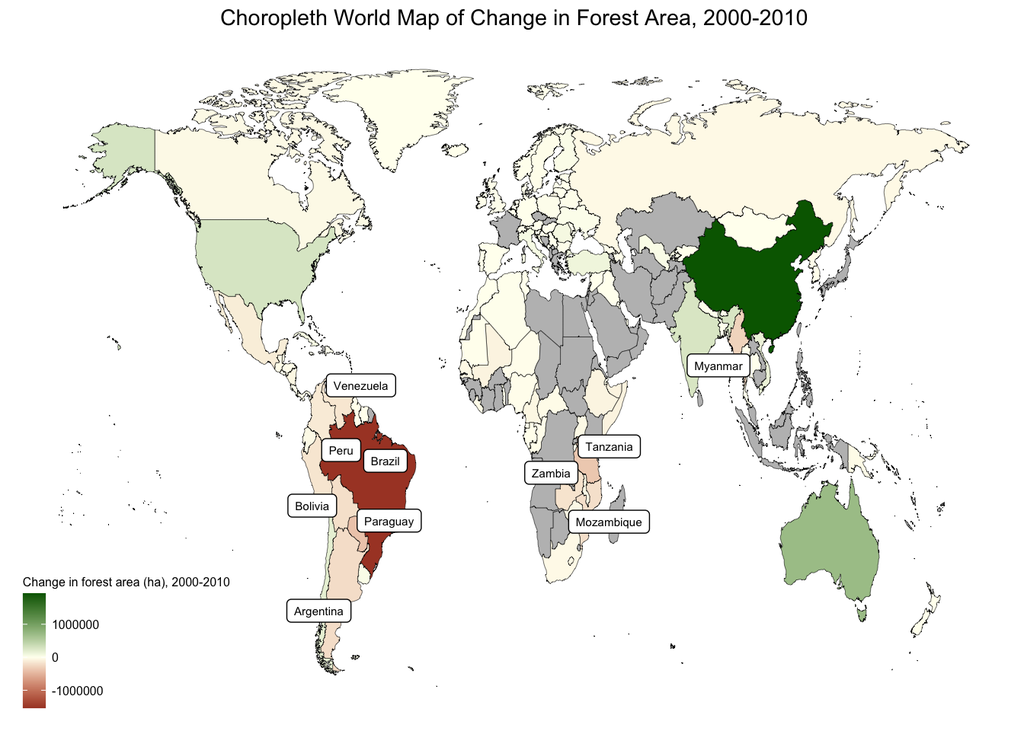

```r
ggplot(data = world) +
  geom_polygon(aes(long, lat, group = group, fill = net_forest_conversion), color = "black", linewidth = 0.1) +
  scale_fill_gradient2(low = "darkred", mid = "ivory", high = "darkgreen", midpoint = 0, na.value = "grey", name = "Change in forest area (ha), 2000-2010") +
  geom_label_repel(data = top10_labels, aes(x = long, y = lat, label = entity), box.padding = 0.02, point.padding = 0.1, segment.size = 0.05, size = 2, force = 5) +
  theme_map() +
  theme(axis.title = element_blank(), axis.text = element_blank(), axis.ticks = element_blank(), legend.key.size = unit(0.4, "cm"), legend.title = element_text(size = 6), legend.text = element_text(size = 6), plot.title = element_text(hjust = 0.5)) + labs(title = "Choropleth World Map of Change in Forest Area, 2000-2010")
```

## 3.3 Discussion

The choropleth map makes it strikingly apparent that Brazil experienced the most significant loss of forests with the darkest shade of red compared to the rest of the world, even much darker than the second most deforested country - Paraguay.

# 4 Scatterplot

## Is there a correlation between soybean use/vegetable oil production and net forest loss? Did these factors have an effect on deforestation in these countries?

We plot scatterplots of Increase in Total Soybean Use (Increase in Total Veg Oil Production) vs Net Forest Loss to investigate the relationship between increased soybean usage (increased vegetable oil production) and deforestation from 2000 to 2010 for each country.

## 4.1 Data Cleaning

Since the amount of missing values in the soybean_use and vegetable_oil data for these countries were too large to ignore (may skew the data and lead to inaccurate conclusions), we filled in missing values in each column with the mean of the remaining countries for that year.

```r
# Prepare the soybean data
top10_soybean_imputed <- soybean_use %>%
  # Keep only data from 2000-2010 from top 10 countries
  filter(year %in% c(2000, 2010), entity %in% top10_countries) %>%
  group_by(year) %>%
  # Fill in NA values with the mean of that column for that respective year
  mutate(human_food = ifelse(is.na(human_food), mean(human_food, na.rm = TRUE), human_food),
         animal_feed = ifelse(is.na(animal_feed), mean(animal_feed, na.rm = TRUE), animal_feed),
         processed = ifelse(is.na(processed), mean(processed, na.rm = TRUE), processed)) %>%
  ungroup()

top10_soybean_change <- top10_soybean_imputed %>%
  # Get the total soybean usage for each country in 2000 and 2010
  group_by(entity, year) %>%
  summarise(total = human_food + animal_feed + processed, .groups = "drop") %>%
  pivot_wider(names_from = year, values_from = total) %>%
  # Get the increase in soybean usage from 2000-2010 for each country by calculating their difference
  mutate(soybean_change = `2010` - `2000`) %>%
  select(entity, soybean_change)

# Repeat same steps on veg oil production data
top10_vegoil_imputed <- vegetable_oil %>%
  filter(year %in% c(2000, 2010), entity %in% top10_countries) %>%
  pivot_wider(names_from = crop_oil, values_from = production) %>%
  group_by(year) %>%
  mutate(Soybean = ifelse(is.na(Soybean), mean(Soybean, na.rm = TRUE), Soybean),
         Sesame = ifelse(is.na(Sesame), mean(Sesame, na.rm = TRUE), Sesame),
         Linseed = ifelse(is.na(Linseed), mean(Linseed, na.rm = TRUE), Linseed),
         Palm = ifelse(is.na(Palm), mean(Palm, na.rm = TRUE), Palm),
         Rapeseed = ifelse(is.na(Rapeseed), mean(Rapeseed, na.rm = TRUE), Rapeseed),
         Groundnut = ifelse(is.na(Groundnut), mean(Groundnut, na.rm = TRUE), Groundnut),
         Cottonseed = ifelse(is.na(Cottonseed), mean(Cottonseed, na.rm = TRUE), Cottonseed),
         `Coconut (copra)` = ifelse(is.na(`Coconut (copra)`), mean(`Coconut (copra)`, na.rm = TRUE), `Coconut (copra)`),
         `Olive, virgin` = ifelse(is.na(`Olive, virgin`), mean(`Olive, virgin`, na.rm = TRUE), `Olive, virgin`),
         Safflower = ifelse(is.na(Safflower), mean(Safflower, na.rm = TRUE), Safflower),
         Sunflower = ifelse(is.na(Sunflower), mean(Sunflower, na.rm = TRUE), Sunflower),
         Maize = ifelse(is.na(Maize), mean(Maize, na.rm = TRUE), Maize),
         `Palm kernel` = ifelse(is.na(`Palm kernel`), mean(`Palm kernel`, na.rm = TRUE), `Palm kernel`),) %>%
  ungroup()

top10_vegoil_change <- top10_vegoil_imputed%>%
  group_by(entity, year) %>%
  summarise(total = Soybean + Sesame + Linseed + Palm + Rapeseed + Groundnut + Cottonseed + `Coconut (copra)` + `Olive, virgin` + Safflower + Sunflower + Maize + `Palm kernel`, .groups = "drop") %>%
  pivot_wider(names_from = year, values_from = total) %>%
  mutate(vegoil_change = `2010` - `2000`) %>%
  select(entity, vegoil_change)

# Join the above data frames with net forest conversion data frame for top 10 countries. This new data frame will be used for ggplot().
top10_change <- top10_forest_change %>%
  left_join(top10_soybean_change, by = "entity") %>%
  left_join(top10_vegoil_change, by = "entity") %>%
  # Perform log transformation of net_forest_conversion
  mutate(log_forest_loss = log(abs(net_forest_conversion)), color = ifelse(entity == "Argentina", "red", "black"))

# Remove outlier for plotting best fit line
top10_change_wo_outlier <- top10_change %>% filter(entity != "Argentina")
```

## 4.2 Visualisation

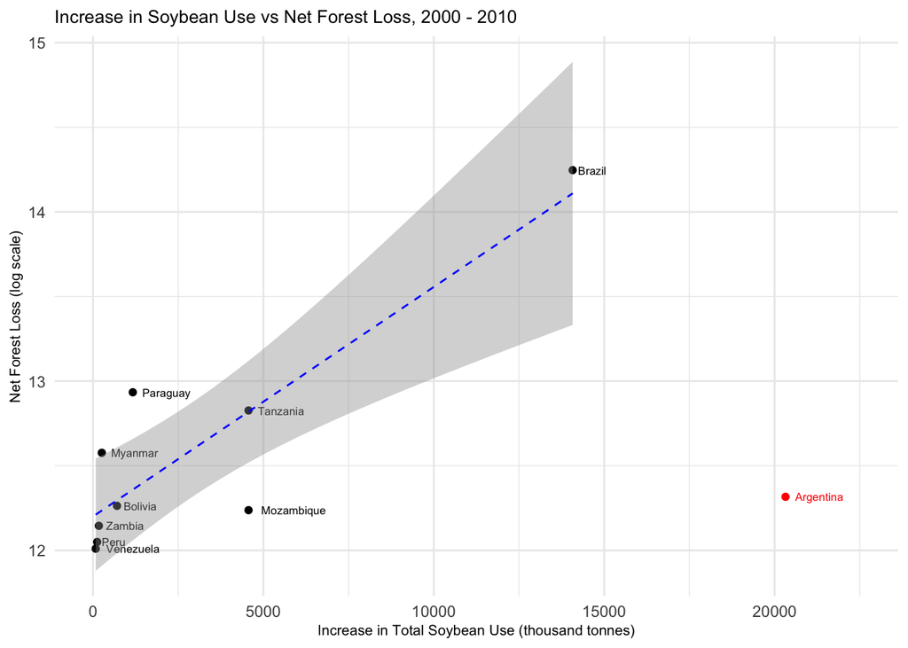

```r
# Plot of Increase in Total Soybean Use vs Log Forest Loss, 2000-2010
ggplot(data = top10_change, aes(x = soybean_change/1000, y = log_forest_loss)) +
  geom_point(aes(color = color)) +
  scale_color_identity() +
  geom_text(aes(label = entity, color = color), size = 2.2, nudge_x = 0.1, hjust = -0.2) +
  xlim(0, 22500) +
  geom_smooth(data = top10_change_wo_outlier,
              method = "lm", color = "blue", se = T, linetype = "dashed", linewidth = 0.5) +
  labs(x = "Increase in Total Soybean Use (thousand tonnes)", y = "Net Forest Loss (log scale)", title = "Increase in Soybean Use vs Net Forest Loss, 2000 - 2010") +
  theme_minimal() +
  theme(axis.title = element_text(size = 8), plot.title = element_text(size = 10))
```

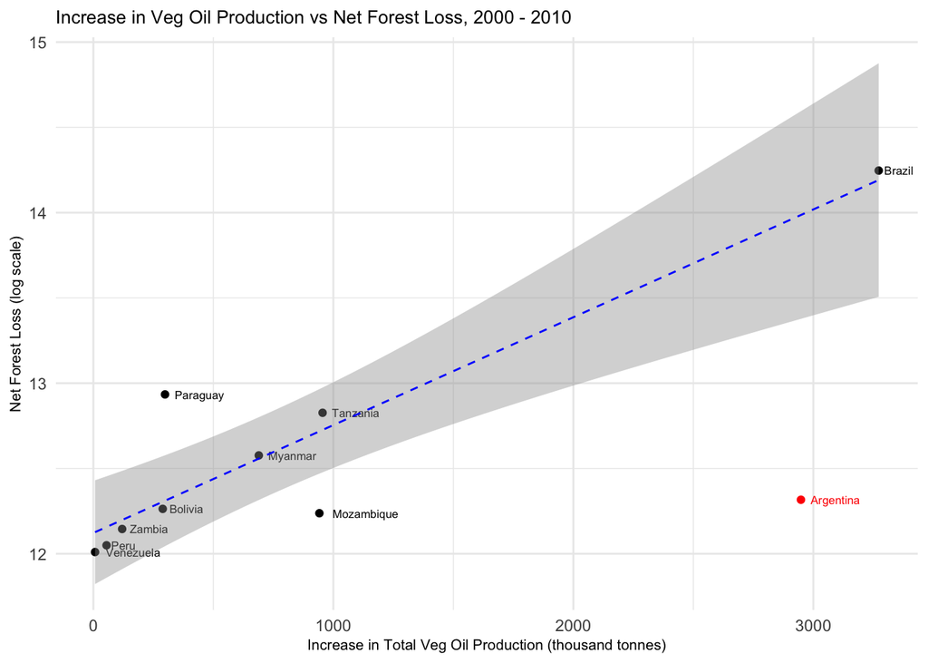

```r
# Plot of Increase in Total Veg Oil Production vs Log Forest Loss, 2000-2010
ggplot(data = top10_change, aes(x = vegoil_change/1000, y = log_forest_loss)) + geom_point(aes(color = color)) + scale_color_identity() +
  geom_text(aes(label = entity, color = color), size = 2.2, nudge_x = 0.1, hjust = -0.2) +
  geom_smooth(data = top10_change_wo_outlier,
              method = "lm", color = "blue", se = T, linetype = "dashed", linewidth = 0.5) +
  labs(x = "Increase in Total Veg Oil Production (thousand tonnes)", y = "Net Forest Loss (log scale)", title = "Increase in Veg Oil Production vs Net Forest Loss, 2000 - 2010") + theme_minimal() +
  theme(axis.title = element_text(size = 8), plot.title = element_text(size = 10))
```

## 4.3 Discussion

From the above plots, we see that countries that had greater increases in soybean usage and veg oil production from 2000 to 2010 experienced greater deforestation in the same time period. There seems to be a positive linear correlation between increase in usage of soybean/production of veg oil and log deforested area, with the exception of Argentina, which was an outlier. This supports our theory that deforestation in these countries may have been driven by soybean use and veg oil production. However, we cannot be 100% certain as correlation does not equal causation. Nonetheless, the insights gained from these two plots form the basis for our final visualisation.

# 5 Barplot

## What were the most popular uses for soybean in each country? What were the most produced types of vegetable oil in each country?

Now that we have discovered a positive correlation between soybean use and vegetable oil production, we are interested in breaking down each into their individual components to find which were the main drivers of soybean use and veg oil production in each country. To achieve this, we plot barplots showing the proportions of each factor in their respective categories, faceted on year and country.

## 5.1 Data Cleaning

To prepare the final data frame for bar plotting, we first manipulate `top10_soybean_imputed` and `top10_vegoil_imputed` into a tidy format by pivoting longer on the factors. We then combine them into a single data frame and remove unnecessary columns before calculating proportions of each factor as we are interested in the relative contribution of each factor to the total soybean use and veg oil production in 2000 and 2010.

```r
# Pivot longer on each factor of soybean use into a single column
top10_soybean_bar <- top10_soybean_imputed %>%
  select(-code) %>%
  mutate(factor = "soybean") %>%
  pivot_longer(cols = c("human_food", "animal_feed", "processed"), names_to = "soybean", values_to = "soybean_val")

# Rename each factor and repeat the above
top10_vegoil_bar <- top10_vegoil_imputed %>%
  select(-code) %>%
  mutate(factor = "oil") %>%
  rename(soybean = Soybean,
         sesame = Sesame,
         linseed = Linseed,
         palm = Palm,
         rapeseed = Rapeseed,
         groundnut = Groundnut,
         cottonseed = Cottonseed,
         coconut = `Coconut (copra)`,
         olive = `Olive, virgin`,
         safflower = Safflower,
         sunflower = Sunflower,
         maize = Maize,
         palm_kernel = `Palm kernel`) %>%
  pivot_longer(cols = c("soybean", "sesame", "linseed", "palm", "rapeseed", "groundnut", "cottonseed", "coconut", "olive", "safflower", "sunflower", "maize", "palm_kernel"), names_to = "oil", values_to = "oil_val") %>%
  group_by(entity, year) %>%
  # Show only the top 5 contributing factors in each country for simplicity and interpretability
  slice_max(oil_val, n = 5)


# Combine the above two data frames into a suitable format for bar plotting
top10_bar <- bind_rows(top10_soybean_bar, top10_vegoil_bar)
top10_bar <- top10_bar %>%
  mutate(val = case_when(
    !is.na(soybean_val) ~ soybean_val,
    !is.na(oil_val) ~ oil_val
  )) %>%
  select(-c("soybean_val", "oil_val")) %>%
  mutate(level = case_when(
    !is.na(soybean) ~ soybean,
    !is.na(oil) ~ oil
  )) %>%
  select(-c("soybean", "oil")) %>%
  group_by(factor, year, entity) %>%
  mutate(fac_total = sum(val)) %>%
  ungroup() %>%
  group_by(entity, year, level) %>%
  # Calculate proportions of each factor in the two drivers
  mutate(prop = val / fac_total)
```

## 5.2 Visualisation

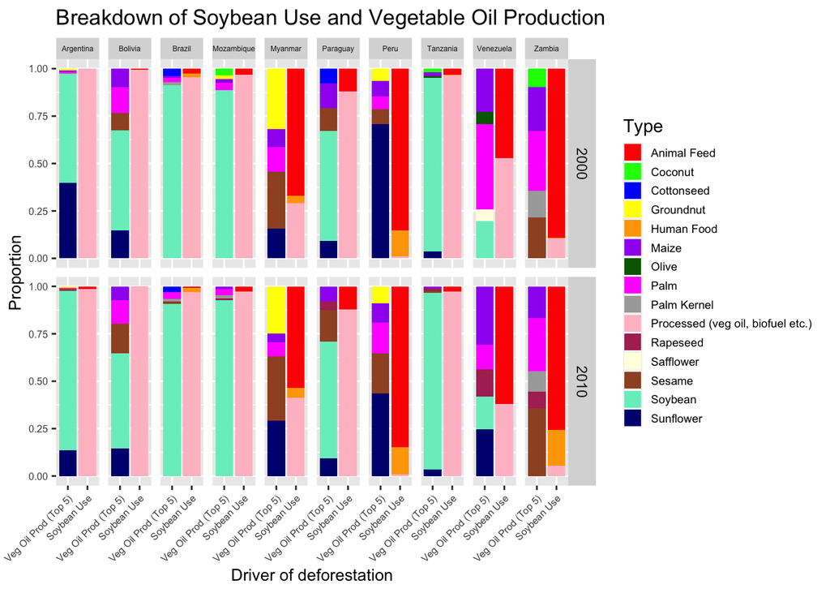

```r
ggplot(top10_bar, aes(x = factor, y = prop, fill = level)) +
  geom_col(position = "fill") +
  facet_grid(rows = vars(year), cols = vars(entity)) +
  scale_fill_manual(values = c("red", "green", "blue", "yellow", "orange", "purple", "darkgreen", "magenta",
            "darkgray", "pink", "maroon", "lightyellow", "sienna", "aquamarine2", "navy", "cyan"), labels = c("Animal Feed", "Coconut", "Cottonseed", "Groundnut", "Human Food", "Maize", "Olive", "Palm", "Palm Kernel", "Processed (veg oil, biofuel etc.)", "Rapeseed", "Safflower", "Sesame", "Soybean", "Sunflower", "Linseed")) +
  labs(x = "Driver of deforestation", y = "Proportion", title = "Breakdown of Soybean Use and Vegetable Oil Production", fill = "Type") +
  scale_x_discrete(labels = c("Veg Oil Prod (Top 5)", "Soybean Use")) +
  theme(axis.text.x = element_text(angle = 45, hjust = 1, size = 6), axis.text.y = element_text(size = 6), strip.text.x = element_text(size = 4.5), legend.text = element_text(size = 7), legend.key.size = unit(0.8, "lines"), plot.title = element_text(size = 13), axis.title.x = element_text(size = 10), axis.title.y = element_text(size = 10), legend.title = element_text(size = 11))
```

## 5.3 Discussion

From the above faceted barplots, we see that in Argentina, Bolivia, Brazil, Mozambique, Paraguay, and Tanzania, the most produced crop oil by far was soybean oil. Incidentally, use of soybean for further processing (vegetable oil, biofuel and processed animal feed) formed the bulk of soybean use in the same countries. This strongly suggests that soybean oil production was a major driver of deforestation in these countries.

In Myanmmar, the most produced vegetable oil in both years was sesame oil while the most popular use for soybean was for animal feed, suggesting that these were major drivers of deforestation in this country.

# 6 Conclusion

# 7 References

1. https://github.com/rfordatascience/tidytuesday/blob/master/data/2021/2021-04-06/readme.md

# 8 About

This project was developed for DSA2101 Essential Data Analytics Tools: Data Visualization at the National University of Singapore (NUS). The team is comprised of the following members:

| Name | Year | Major | Responsibilities |
| --- | --- | --- | --- |
| FONG KANG WEI | 2 | Data Science & Analytics | Sections 1, 3 and 6 |
| A M NOORUL NAGIEB | 2 | Data Science & Analytics | Sections 4 and 6 |
| XIE ZEBANG | 2 | Data Science & Analytics | Sections 5 and 6 |